# BM432 Data Visualisation

Morgan Feeney

University of Strathclyde

Leighton Pritchard

University of Strathclyde

2024-10-23

# 1. Introduction

## Learning Objectives

- You should be able to critically analyse how data is visualised
- You should be able to judge a figure’s clarity and potential for misunderstanding
- You should be able to identify potential sources of bias resulting from the visualisation
- You should understand how to create effective figures for your own work

## Background Reading

- Introduction to Data Visualisation
  - https://sipbs-compbiol.github.io/BM432/notebooks/04-data_presentation_workshop.html
- Interactive Data Visualisation examples
  - https://sipbs-bm432.shinyapps.io/03-04a-barchart/
- Additional information:
  - [“Fundamentals of Data Visualisation” *by Claus O. Wilke*](https://clauswilke.com/dataviz/)
  - [“Data Visualisation: A Practical Introduction” *by Kieran Healy*](https://socviz.co/index.html#preface)
  - “Points of View: graphic design for data visualisation”

## Exercise: Four figures (assess all figures)

- Use the DOIs provided to find the papers the figures are from, if you need more information than is in the figure legend
- **For each figure, consider the following:**
  - What type of data is being presented?
  - Are the data presented effectively? (why/why not?)
  - How might the data presentation be improved?
  - How would you grade this figure according to University Marking Guide B?
- Fill in the *pro forma* with your scoring and free-text answers to the questions above (one sentence each)
  - [Google Form](https://forms.gle/cyJPnnuvVRazcTkk7)

# 4. Individual Figures

## Figure 1 (doi:10.1073/pnas.2320257121)

- Suggested improvements:
  - The lower extent of error bars is not visible in (B), (D), (G), or (E). Avoid “dynamite plots.”
  - Bar charts should be avoided; 1D scatterplot for (D), (G), and (E) would be clearer. Line plot with concentration on $x$-axis would improve (B).
  - We can’t see difference between effects of two concentrations of A16 in (D), or A16 vs A18 in (B); use a table of contrasts.
  - Place things to be compared by the reader next to each other where possible (E).

## Figure 1 (doi:10.1073/pnas.2320257121)

| improvements |
| --- |
| reorganising in a way that flows slightly better to the eye |
| Worth noting that whilst the bar charts they have used are easy to read, they might not be representative of any distribution in results. Alternatives might be histograms or violin plots. |
| Show data points in scatterplot or box plot |
| I think the figure legend could be more detailed |
| The scales on the bar charts are all different so at a glance makes the results seem more similar |
| better spacing more accurate number |
| Could box off panels to make more distinct from one another; |
| Perhaps the error bars on panel B were too large i.e. took up half the space on the graph and could’ve been presented differently |
| Re-organized |
| remove the numbers on the bars, have all backgrounds the same colour eg white or black in Figure C, have a chart at the side displaying what colour of bar is what group instead of putting each group n… |
| Colour shading could be improved, difficult to distinguish between subset of bars |
| Colour scheme could be easier to see - could be difficult to tell the difference in shades |
| I think the colours in the bar charts could be clearer. |
| I believe if dot plots were also plotted so you could see first hand the variation of the data sets. |
| roviding clear visual representations, detailed legends, and contextual information will aid in communicating the significance of the research. |
| make bar section for A18 on part E as well |
| simplify each colour section |
| The layout of the different components of the figure could be improved. It is not appealing and does not flow very well, making it a bit harder to interpret. To improve the components should all be of… |
| no idea |
| it can be improved by making the text size consistent throughout |
| unsure |
| Not sure how to fix because they are comparing so many bars in B |
| n/a |
| More text on the diagrams, the layout of the various diagrams can be adjusted so that they can be better compared with each other to convey meaning |
| keep all the different kinds of figures together e.g. bar graphs along side bar graphs, images along side images |
| making the figures easier to read |
| maybe less is more |
| molecular weight |
| I think it is presented well. |
| Presenting all the graphs in the same size, making use of more white space as well as using a box plot combined with scatter plot or at least use scatter and the bar. |
| better use of colours |
| Not sure |
| not sure |
| Mention the N numbers either on the graphs or in the legend instead of just saying at least 3. Maybe try and use other symbols to represent significance lines and clarify what’s being compared in the … |
| Same colour/shade for same concentration of a particular constituant |
| bigger labels maybe |
| Use box and whisker plots with data points overlayed? |
| Maybe grouping together certain parts of the data to allow better comparison |
| there isnt much difference in the colour gradient of the green, changing the middle column to a slightly darker colour would make the difference more clear |
| No requirement to state no significance. |
| Figure E need a bit of correction as it might be better labelled |
| n/a |
| not sure :/ |
| Could be spaced out more, quite cramped |
| I wouldve liked to see the actual scale bar with the values on the visualisations of the fibroblasts and not just on the figure legend, but this could make the figure look a bit too busy. |
| The layout can be improved. Put the same kind of charts together. |
| Split into smaller grouped info |
| make all parts the same size |
| explaining any abbreviations e.g. DMSO |
| Individual data points could be shown. Perhaps a boxplot with jittered scatter plot. |
| N/A |
| split up into separate figures to make info more digestable |
| The data presentation in this figure could be improved by increasing the font size of labels and numbers in the bar graphs for better readability, and explicitly stating the exact sample sizes for eac… |
| more what to look at instructions of the immunofluorescence confocol image |
| a few things i would do differently would be the stats. the way they are layed out makes it harder to read for me personally but i can see how this might be useful for other people |
| the treatment length was different for each group, should been the same, because then they are not really comparable. |
| n/a |

## Figure 2 (doi:10.1073/pnas.2405474121)

- Suggested improvements:
  - UMAP plots (B, E) are highly manipulable and clustering/placement does not necessarily reflect objective measures.
  - Unpleasant colour choices in (C); there is room for aesthetic improvement.
  - The proportion plot in (C) does not give information on absolute number, only proportion; a proportional areas plot spanning all clusters would more honestly represent the data.
  - Heatmap text is too small to read comfortably; is there too much data here?

## Figure 2 (doi:10.1073/pnas.2405474121)

| improvements |
| --- |
| snapshot of D and reoutput of C |
| Including more white space, improving figure legend, alternative methods of data visualisation. |
| Simplied figures, less unessessary colour and text |
| make the figure legend more straightforward |
| make some text bigger |
| less colours and images made bigger |
| less colours and less content heavy data, split into more figures |
| the presentation could be improved by adding more detailed descriptions of the statistical methods for each figure, particularly for the transcription heatmaps, and including more explicit explanation… |
| The presentation could be improved by adding more detailed descriptions of the statistical methods for each figure, particularly for the transcription heatmaps, and including more explicit explanation… |
| shouldve been split into seperate figures to allow the reader to understand all of them |
| present the data in an easier, more readable format - some forms i.e. particularly panel C do not actually explain what is going on in the figure, just stating the type of graph used |
| maybe explain what each figure actually shows |
| Space out the rows in C as hard to follow across |
| Specifically part D of the figure is harder to decipher due to the small text. |
| label more stuff explain why the genes are relevant |
| Tidy up |
| Selection of key data and highlighting of relevant information in different characters |
| Less info |
| change to colour scheme and layout of all graphs. Statistical data (e.g. sample size) needs to be included in legend. |
| I’m not sure what the best option for this data would be |
| less bright colours and more monochromatic colours |
| Could be formatted differently or separated into different figures. |
| Perhaps by seperating the figure into two parts it would make it easier to focus on the information rather than having it all in one, or else if possible reducing the amount of names in the Y axis in … |
| I think that they can reduce the number of figures |
| Clearly define the borders/limits of each figure |
| . |
| increase space in between sections so they are clearer to distinguish e.g. between a and b |
| add full borders around each part might help reading flow |
| no |
| Genuinely? Haven’t a clue |
| Perhaps breakdown the heatmap into parts or focus on key results only. |
| I think less colour could have been used as the data would not be interpretable to a colour blind audience. I also think a collection of smaller bar charts for C instead would be better |
| split it up, explain what each par is |
| Could be improved by adding in some qauntifiable data with better figure legends i.e explaining what UMAP actually means. |
| better organisation for one |
| Less colours |

## Figure 3 (doi:10.1073/pnas.2408540121)

- Suggested improvements:
  - The lower extent of error bars is not visible in (D) or (E). These are “dynamite plots,” which should be avoided.
  - Bar charts should be avoided in general; a 1D scatterplot of each dataset in (D) and (E) would be clearer.

## Figure 3 (doi:10.1073/pnas.2408540121)

- Suggested improvements (MF):
  - Failure to complement the triple mutant strain???
  - Fluorescence wavelength not specified (C)
  - Colour scheme in (A) is inconsistent
  - Axis label in (B) could be improved
  - Figure legend for (A) could be more succinct/some of this info should be in the paper text instead

## Figure 3 (doi:10.1073/pnas.2408540121)

| improvements |
| --- |
| Perhaps the flow of the figure could be improved. The way the individual panels are labelled (A-E) doesn’t appear to have as logical a flow as it could. |
| State what the appreviations mean |
| By using a larger number scale for figure D and also a larger figure in general |
| reordering of panels - this didn’t make sense to me as it read in a very confusing way |
| I think using a bar graph for parts D and E was not so easy to understand as it is just an average of all four so does not give much information |
| changing the colour/ shading of parts D and E to make the genotype bars more different |
| perhaps label in different order; diagram A, growth curve B, 2 bar graphs C and D, and photographs as E |
| - |
| it couldve been improved by using slightly more contrasted colours in the d and e diagrams which maybe couldve matched with figure b like the orange |
| had to look up every 2nd word |
| Figures 1D & 1E could be presented as box plots to convey statistical information about the data. |
| Signalling pathway maps can be further annotated with key information such as NAG etc. |
| use scatter plots instead of bar charts |
| using the same colours for the mutation and control groups in all figures |
| Part B in the legend mentions “Growth curve in TY.”, unless I am missing something, I don’t see what this means anywhere. Maybe it is a microbiology term I am not familiar with since I do biomedical s… |
| N/A |
| N/A |
| not sure |
| Have more line spacing to make the figure legend easier to read |
| By adding colour to some of the diagrams. |
| Unsure |
| maybe colour coding the bar charts |
| the bar graphs ideally need to be shades further apart and the label on C i would put at the top as opposed to in the figure |

## Figure 4 (doi:10.1073/pnas.240342112)

- Suggested improvements:
  - The rifampicin structure is purely dewxcorative and could be removed.
  - The lower extent of error bars is not visible in (B). This is a “dynamite plot,” which should be avoided.
  - Bar charts should be avoided in general; a 1D scatterplot of each dataset in (B) would be clearer.
  - The implied membrane in (C) and (D) could be stated as such in the figure.

## Figure 4 (doi:10.1073/pnas.240342112)

| improvements |
| --- |
| im not sure |
| Change figure A |
| Different colours, as green salmon and gold don’t look too appealing tt=ogether |
| Change A to a bar graph, showing significance values and actual analysis, move western blotting to perhaps B where mutant type is more relevant and add significance to B. Simplify C and D to become mo… |
| its confusingly laid out, with B under A rather than across from it the author also doesn’t make it clear what the red boxes are around the western blot results the author also should’ve plotted the r… |
| explain why the structures are relevant |
| less boring |
| Addition of two-factor data analyses and representation on graphs |
| changing colour schemes and including statistical data |
| Arrange the figure legend just slightly to flow more smoothly with the movement of the figure. Instead of (A) in the legend going top, bottom then middle, follow the direction of the figure - top, mid… |
| There was no statistical analysis on the bar graph. |
| use more colour-blind friendly colours |
| NA |
| Explaining the significance of the structural figures in the context of the study |
| The inclusion of showing the wild type and E161Q western blot doesn’t feel like it should be in the same section of the figure as the rifampicin and ethambutol plates |
| split the protein structures into a different figure |
| for one increase the size of the structure of rifampicin and have it as a part A or remove it completely |

# 5. Summing Up

## General Comments

- Colour choices
- Larger figures/graphs, more space between figures/graphs
- Too much data per figure
- Split into multiple figures
- Remove unnecessary data (how do we define this?)
- “The data is presented in a manner that would likely be inaccessible for people without prior experience. A move toward a more palatable/digestible format will facilitate better science communication in the future.”

## Visualising Data About Data Visualisation

- What did you say about figure effectiveness?

[interactive chart not shown]

## Visualising Data About Data Visualisation

- What words did you use to describe potential figure improvements?

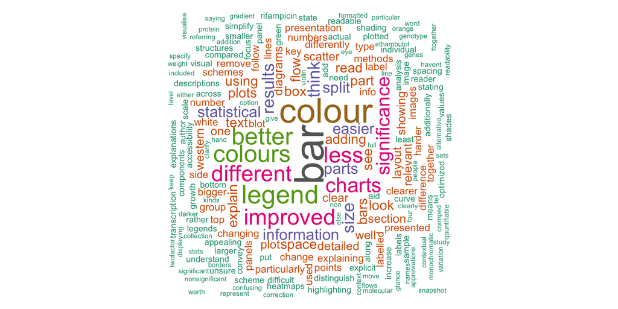

## Data Visualisation is Not Neutral

[figure not shown]

[figure not shown]